# Math 490 Test #1

Maxwell Levin

February 9, 2018

## Problem 1 (20 Pts)

#### You roll two fair dice and label the two observed values $\small{X}$ and $\small{Y}$. You will be rewarded $\small{W = |2X - Y|}$ dollars.

#### a. (3 Pts) Find the p.m.f. of $\small{W}$.

The p.m.f. of $\small{W}$ is as follows:

```
       0    1    2    3    4    5    6    7    8    9    10   11
p.m.f. 3/36 5/36 5/36 4/36 4/36 3/36 3/36 3/36 2/36 2/36 1/36 1/36
```

#### b. (4 Pts) Find $\small{E(W)}$ and $\small{SD(W)}$.

We calculate $\small{E(W)}$

$$E(W) = 0\left(\frac{3}{36}\right) + 1\left(\frac{5}{36}\right) + \dots + 11\left(\frac{1}{36}\right) \approx 4.222$$

We calculate $\small{Var(W)}$

$$Var(W) = (0 - 4.22)^2\left(\frac{3}{36}\right) + (1 - 4.22)^2\left(\frac{5}{36}\right) + \dots + (11 - 4.22)^2\left(\frac{1}{36}\right) \approx 9.006.$$

Thus we see that

$$SD(W) = \sqrt{Var(W)} \approx 3.001.$$

#### c. (3 Pts) Use R to sample 1024 values from the distribution of $\small{W}$. Make a histogram of the 1024 observed values and comment on the shape of the histogram. Also report the mean and the standard deviation of the observed values.

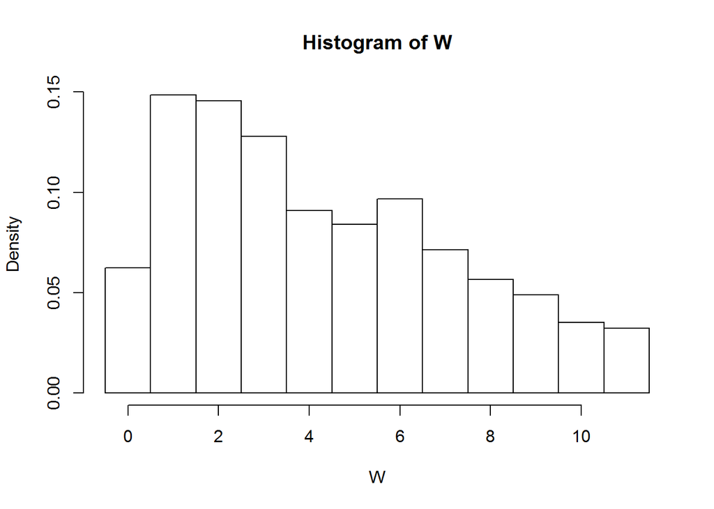

```r
X = sample(1:6, 1024, replace=T)
Y = sample(1:6, 1024, replace=T)
W = abs(2*X - Y)
hist(W, breaks=seq(-0.5, 11.5, 1), prob = T)
```

The histogram for this plot looks about like what one would expect based on the p.m.f. of $\small{W}$: The most frequent values for $\small{W}$ are 1 and 2. We see that 0, 3, 4, 5, 6, and 7 are all about as likely as each other, and 8, 9, 10, and 11 are less frequent.

The mean of $\small{W}$ is

```
[1] 4.28418
```

The standard deviation of $\small{W}$ is

```
[1] 3.009646
```

Both the mean and the standard deviation are reasonably close to our calculations in (b).

#### d. (3 Pts) Roll the two fair dice repeatedly for $\small{n = 9}$ times and label the observed values by $\small{(X_i,Y_i), i = 1,2, \dots, 9}$. Let $\small{W_i = |2X_i - Y_i|, i = 1,2, \dots, 9,}$ and let

$$\overline{W_9} = \frac{W_1 + W_2 + \dots + W_9}{9}.$$

#### Find $\small{E(\overline{W_9})}$ and $\small{SD(\overline{W_9})}$.

We know from a similar problem on HW #3 that the sample mean does not change with sample size. That is,

$$E(\overline{W_9}) = E(W) \approx 4.222.$$

Additionally, we know that our standard deviation decreases by the square root of our sample size. That is,

$$SD(\overline{W_9}) = \frac{1}{3}SD(W) \approx 1.000.$$

#### e. (3 Pts) Use R to generate 1024 sample means $\small{\overline{W_9}}$. Make a histogram and comment on the shape of the simulated sample means. Also report the mean and the standard deviation of the simulated sample means.

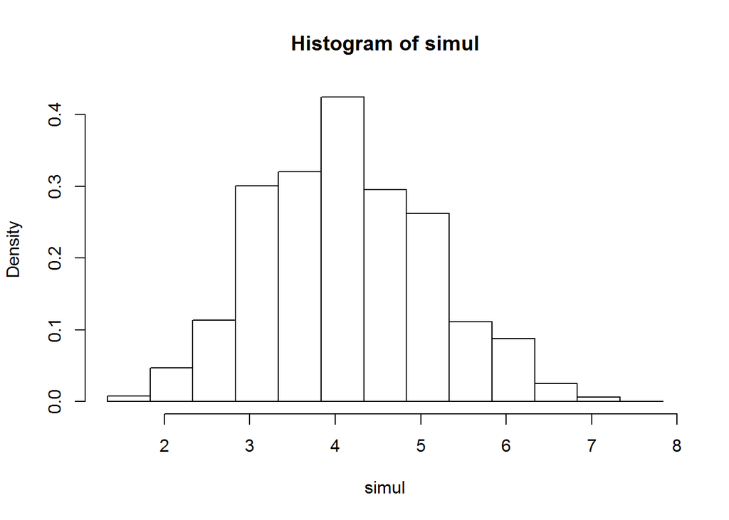

```r
prob1e = function(sam, rep) {
  obs = NULL
  for (i in 1:rep) {
    X = sample(1:6, sam, replace=TRUE)
    Y = sample(1:6, sam, replace=TRUE)
    W = abs(2*X - Y)
    obs = c(obs, mean(W))
  }
  obs
}
simul = prob1e(9, 1024)
hist(simul, breaks=seq(min(simul), max(simul)+1, 0.5), prob=T)
```

This plot looks more or less like a normal distribution centered somewhere between 4 and 4.5. This is more or less what we expect, as the central limit theorem would suggest that as we increase $\small{n}$ our plot of sample means becomes more and more like a normal distribution even though our initial distribution, $\small{W}$, was not normally distributed.

The mean of our sample means is

```
[1] 4.155382
```

The standard deviation is

```
[1] 0.9929663
```

These are both near the values we calculated in part (d).

#### f. (2 Pts) Use a normal probability plot to assess the normality of the 1024 sample means simulated in part (e). Verbally assess the normality of $\small{\overline{W_9}}$ based on the plot.

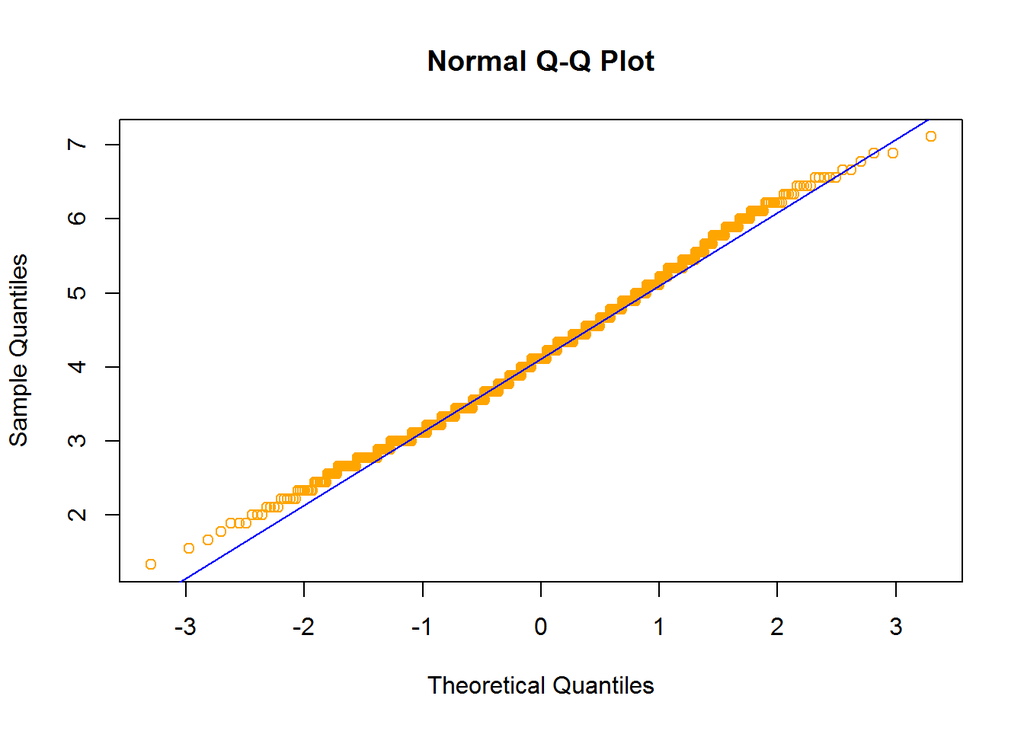

Our normal probability plot seems to indicate that our distribution is fairly normal, as the Q-Q plot above looks linear for the majority of the plot.

#### g. (2 Pts) Use the Shapiro-Wilk test to assess the normality of the 1024 sample means simulated in part (e). Verbally assess the normality of $\small{\overline{W_9}}$ based on the P-value.

```
    Shapiro-Wilk normality test

data:  simul
W = 0.99351, p-value = 0.0001942
```

## Problem 2 (24 Pts)

#### Let random variable $\small{X}$ have the following probability density function.

$$f(x) = \left\{
\begin{array}{ll}
\frac{x}{50} & 0 \leq x\leq 10; \\
0 & \text{otherwise.} \\
\end{array}
\right.$$

#### a. (2 Pts) Find the 0.6-quantile of $\small{X}$.

We calculate the 0.6-quantile, $\small{\xi}$,

$$0.6 = \int_0^{\xi} \frac{x}{50} dx,$$
$$0.6 = \frac{\xi^2}{100}$$
$$\xi \approx 7.746.$$

#### b. (3 Pts) Find $\small{E(X)}$ and $\small{SD(X)}$.

We calculate $\small{E(X)}$ by

$$E(X) = \int_0^{10} \frac{x^2}{50} dx \approx 6.667.$$

We calculate $\small{Var(X)}$

$$Var(X) = E(X^2) - E(X)^2,$$
$$E(X^2) = \int_0^{10} \frac{x^3}{50} dx = 50,$$
$$Var(X) = 50 - (6.667)^2 \approx 5.556.$$

That is, $\small{SD(X)}$ is

$$SD(X) = \sqrt{Var(X)} \approx 2.357.$$

#### c. (3 Pts) Find the c.d.f. $\small{F(x)}$ of $\small{x}$.

The c.d.f. $\small{F(x)}$ of $\small{x}$ is

$$F(x) = \left\{
\begin{array}{ll}
1 & x > 10 \\
\int_0^x f(t) dt & 0 \leq x\leq 10; \\
0 & x < 0. \\
\end{array}
\right.$$

That is,

$$F(x) = \left\{
\begin{array}{ll}
1 & x > 10 \\
\frac{x^2}{100} & 0 \leq x\leq 10; \\
0 & x < 0. \\
\end{array}
\right.$$

#### d. (2 Pts) Find the inverse $\small{F^{-1}(y)}$ of the c.d.f. $\small{F(x)}$ of $\small{x}$.

We can say

$$F(x) = y = \frac{x^2}{100},$$
$$x = \sqrt{100y},$$
$$F^{-1}(y) = 10\sqrt{y}.$$

We care about this for $\small{ 0 \leq y \leq 1}$.

#### e. (4 Pts) Use R to run the CDF inverse method to sample 10000 values from $\small{X}$. Then make a histogram, add the density curve to histogram, and report the 0.6-quantile, the mean, and the standard deviation of the 10000 observed values.

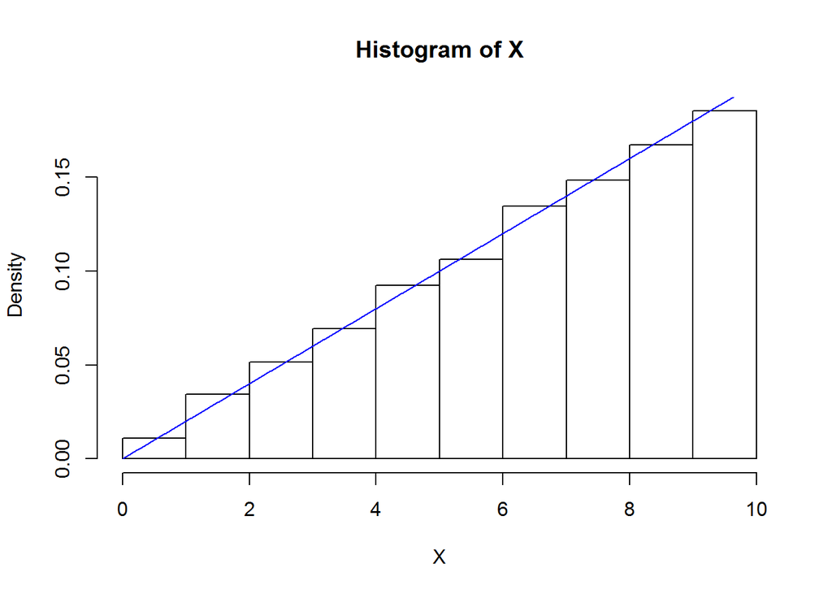

```r
cdfInv = function(n) {
  U = runif(n)
  10*sqrt(U)
}
X = cdfInv(10000)
hist(X, breaks=seq(0, max(X)+1), prob=T, xlim=c(0,10))

x = seq(0, 10, 0.01)
y = ifelse( x >= 0 & x<= 10, x/50, 0 )
lines(x, y, col="blue")
```

The 0.6-quantile is

```
     60%
7.701764
```

The mean is

```
[1] 6.619708
```

The standard deviation is

```
[1] 2.377777
```

#### f. (3 Pts) Let random variables $\small{X_1, X_2, \dots, X_{25}}$ be independent and identically distributed as $\small{X}$. Let

$$\overline{X_{25}} = \frac{X_1 + X_2 + \dots + X_{25}}{25}.$$

#### Find $\small{E(\overline{X_{25}})}$ and $\small{SD(\overline{X_{25}})}$.

We know that $\small{E(\overline{X_{25}})}$ is the same as $\small{E(X)}$ that is,

$$E(\overline{X_{25}}) = E(X) \approx 6.667.$$

Additionally we know that standard deviation decreases by a factor of the square root of the sample size, ie

$$SD(\overline{X_{25}}) = \frac{1}{5}SD(X) \approx 0.4714.$$

#### g. (3 Pts) Use R to generate 1024 sample means $\small{\overline{X_{25}}}$ defined in part (f). Make a histogram and comment on the shape of the simulated sample means. Also report the mean and the standard deviation of the simulated sample means.

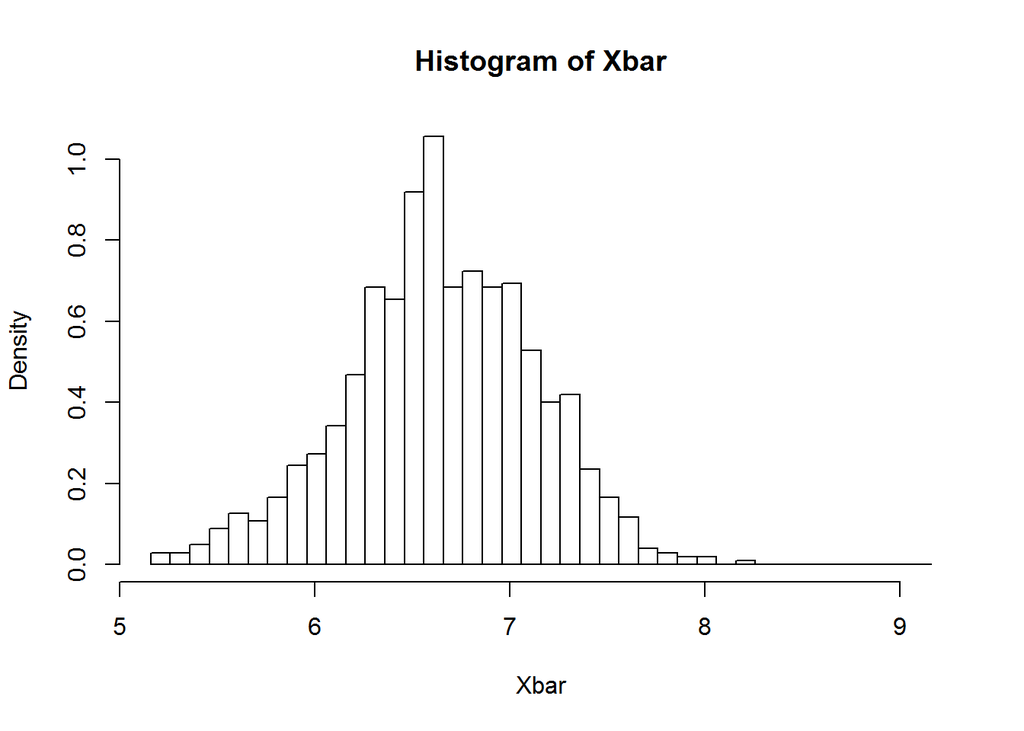

```r
clt = function(sam, rep) {
  obs = NULL
  for(i in 1:rep) {
    xbar = mean(cdfInv(sam))
    obs = c(obs, xbar)
  }
  obs
}

Xbar = clt(25, 1024)
hist(Xbar, breaks=seq(min(Xbar), max(Xbar)+1, 0.1), prob=T)
```

The sample means look normally distributed, which is what we expect from the central limit theorem.

The mean is

```
[1] 6.647902
```

The standard deviation is

```
[1] 0.4825587
```

#### h. (2 Pts) Use a normal probability plot to assess the normality of the 1024 sample means simulated in part (g). Verbally assess the normality of $\small{\overline{X_{25}}}$ based on the plot.

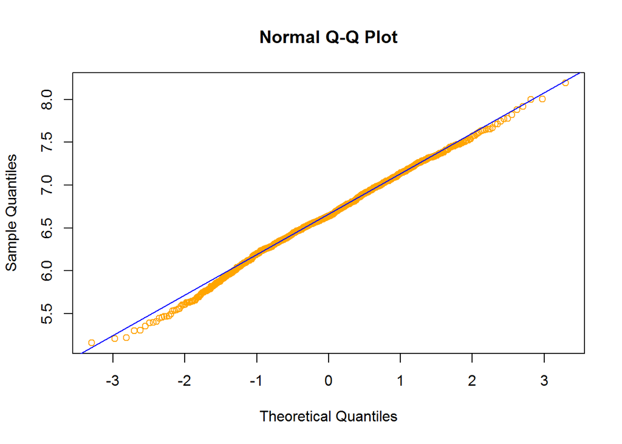

This distribution looks fairly normal according to our probability plot.

#### i. (2 Pts) Use the Shapiro-Wilk test to assess the normality of the 1024 sample means simulated in part (g). Verbally assess the normality of $\small{\overline{X_{25}}}$ based on the P-value.

```
    Shapiro-Wilk normality test

data:  Xbar
W = 0.99702, p-value = 0.05311
```

Our Shapiro-Wilk test indicates weak to no evidence for normality.

## Problem 3 (6 Pts)

#### a. (3 Pts) Use the linear congruential generator (LCG)

$$x_{n+1} \equiv (16897x_n + 2836) \text{ mod } 2147483647$$

#### with seed $\small{x_0 = 0}$ to generate 5000 random numbers $\small{X_i}$. Then make a correlation plot $\small{(X_i, X_{i+1})}$ for $\small{i = 1, 2, \dots, 4999}$. What can we conclude based on the correlation plot?

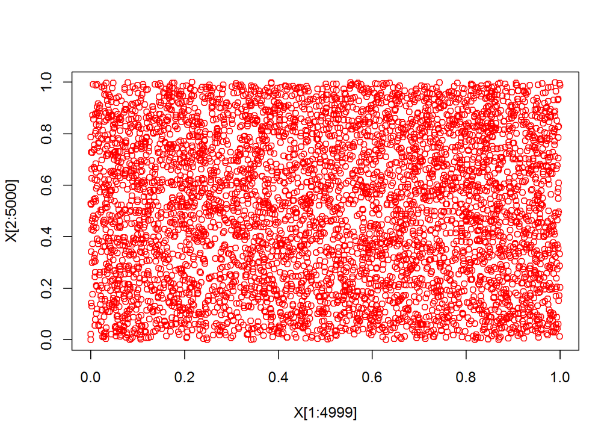

```r
lcg = function(n, slope, intercept, mod, seed=0) {
  output = seed
  for (i in 1:n) {
    x = (slope*seed + intercept) %% mod
    output = c(output, x)
    seed = x
  }
  output/mod
}

X = lcg(5000, 16897, 2836, 2147483647)

plot(X[1:4999], X[2:5000], col="red")
```

This plot looks pretty random, so we can say that there is no correlation between consecutive numbers generated by our LCG with the specified parameters.

#### a. (3 Pts) For the linear congruential generator (LCG)

$$x_{n+1} \equiv (2x_n + 1) \text{ mod } 2^{16},$$

#### explain why this LCG cannot generate more than 17 distinct numbers and it will always end with the number 65535.

Let $\small{x \in \mathbb{Z_{2^{16}}} }$ ($\small{\mathbb{Z}}$ mod $\small{2^{16}}$) be arbitrary. Consider the following,

$$2 [x] + [1],$$
$$2^2[x] + 2[1] + [1],$$
$$\vdots$$
$$2^{16}[x] + 2^{15}[1] + \dots + 2[1] + [1].$$

Examine the line

$$2^{16}[x] + 2^{15}[1] + \dots + 2[1] + [1],$$
$$= [0] + 2^{15}[1] + \dots + 2[1] + [1],$$
$$= 2^{16}[1] - [1],$$
$$= [2^{16} - 1] = [65535].$$

If we continue the process we see

$$2[2^{16} - 1] + [1]$$
$$= [0] - [2] + [1] = [-1] = [65535].$$

Thus no matter what our choice of $\small{x}$, i.e. our seed, our linear congruential generator will always give us 65535 after a maximum of 17 iterations. To rephrase: after 17 or more iterations from any starting seed this LCG will always end with the number 65535.

Consider the following sequence of our lcg with seed 0

```
 [1]     0     1     3     7    15    31    63   127   255   511  1023
[12]  2047  4095  8191 16383 32767 65535
```

Thus we see that there is at least one sequence with 17 distinct elements. Since all sequences repeat after at most 17 iterations, the existence of the sequence above implies that there are at most 17 distinct numbers that our LCG can produce.